# How thinking changes

Week 3 · Chapter 2 · Cognitive and Language Development

Study · Week 3

Read Chapter 2 of the textbook (Eggen & Kauchak, 2025) before you read this brief. The chapter presents three theorists who disagree about where thinking comes from.

About 20 minutes: reading, one place you stop and write, and 8 quick checks.

Pair this with **the Walkthrough**, a 14-minute video in which I analyze the case through one lens and then argue against my first answer.

## The claim you already believe

**Many people believe that children are small adults who know less**, and that development is the process of filling them with knowledge. If that were true, teaching would only be a problem of delivery.

Your own life offers evidence against this belief. Think of something you understand now that you could not have understood at fourteen. Choose a *kind of thinking* that was unavailable to you then, and leave aside the facts you simply had not learned. Most people find an example in seconds.

Nobody gave you that way of thinking by telling you about it.

## Piaget: equilibrium and its disruption

Chapter 2 presents the concepts below. Learn them in this form, because you will use them every week for the rest of the semester:

Developmentally ready: pre-assess to find where students actually are. Readiness has to be measured, because the curriculum’s expectation may not match what students can do.

Schema: an existing conceptual framework. Learners use the schemas they already have to interpret new information.

Equilibrium: the comfort zone. New information fits, so nothing has to change.

Disequilibrium: disruption of the comfort zone. New information does not fit. The experience is uncomfortable, and it drives development in Piaget’s theory.

Assimilation: expansion of the comfort zone. The learner adds the new case to a schema that already exists, which takes little effort.

Accommodation: transformation of the comfort zone. The learner rebuilds the schema itself. This takes great effort, and it is what learning actually is.

Rejection: denial, bias, dissonance. The learner discards the evidence so that the schema can survive. Rejection takes little effort and is extremely common.

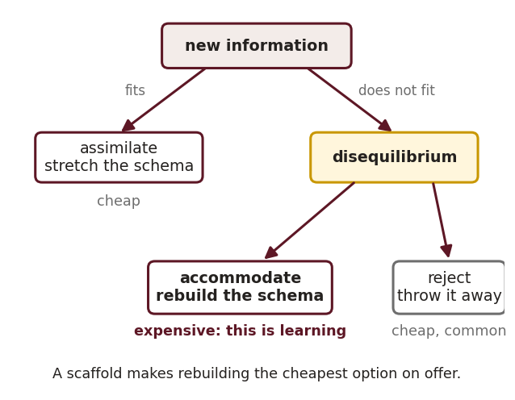

What can happen when new information arrives. Only accommodation is learning in Piaget’s sense, and it takes the most effort.

True or false?

Assimilation is when a learner rebuilds a schema to fit new information.

Not quite Rebuilding is **accommodation**. In assimilation, the learner adds the new case to the schema they already had, and nothing is rebuilt.

Right Assimilation stretches the schema. Accommodation rebuilds it.

**Rejection is not in most textbook summaries, and it should be.** It explains why showing people that they are wrong so often produces a more confident version of the same belief. When accommodation demands enough effort, rejection becomes the rational choice, and your students make that choice constantly about your subject.

Check yourself

A student who says *“I’m just not a math person”* solves a hard problem correctly, then says it was luck. In Piaget’s terms, this is:

Something was discarded Assimilation adds the case to a schema. Here the student explains the evidence away.

The schema survived Accommodation would mean rebuilding the belief. *“Luck”* keeps it intact.

Yes The student discards the evidence so that the schema can survive. This response is easy, comfortable and very common.

There was a mismatch The correct answer did not fit the belief. That is disequilibrium, resolved by rejection.

Commit first

You have designed a lesson that makes students genuinely uncomfortable, because their existing belief about your topic clearly does not work on the case you have given them. Half the class is frustrated. One student says *“can you just tell us the answer?”*

**Has your lesson failed?** Answer in two or three sentences, and say what your answer depends on.

**The lesson is working so far, and its success depends on what you do in the next ten minutes.**

Disequilibrium is the condition under which accommodation becomes possible. When nobody in a lesson is uncomfortable, every student has assimilated: they absorbed the new material into what they already thought and rebuilt nothing.

Discomfort alone does not produce accommodation, because the learner can still choose among three outcomes and two of them take little effort. Sustained frustration with no path forward reliably produces **rejection** (*this subject is stupid, I’m just not a math person*), which is a stable and comfortable resolution that costs the student nothing.

For this reason, a good response to *“can you just tell us?”* is a scaffold that gives enough support to make rebuilding the easiest available option.

Vygotsky’s theory explains how that support works.

## Vygotsky: thinking is social first

Piaget describes the child as a lone scientist who runs experiments on the world and revises private theories. Vygotsky disagrees on a fundamental point: **higher mental functions begin between people and only later move inside.**

Zone of proximal development: what a learner can do *with support* but not yet alone. The zone lies between what learners can already do and what is far beyond them. Teaching has an effect inside this band.

True or false?

The zone of proximal development is the set of tasks a learner can already do alone.

Not quite What a learner can do alone is the inner circle. The ZPD is the ring around it, which contains what they can do **with support** but not yet alone.

Right The ZPD is the band between what learners can do alone and what they cannot do yet. It contains what they can do with support.

Scaffolding: support calibrated to the learner, and withdrawn as competence grows. Scaffolding has three properties: progressive, differential and faded. When support is never withdrawn, it becomes a dependency.

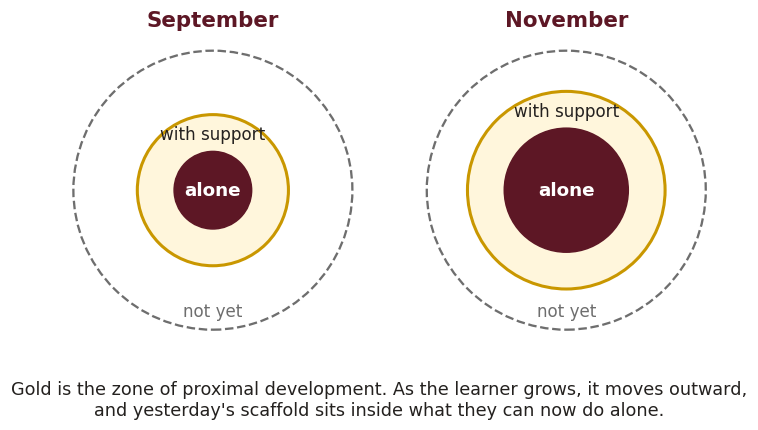

The zone of proximal development in September and November. The zone moves, so the scaffold has to move with it.

**The zone moves.** It depends on the student, the task and the support at a moment in time, so it is not a fixed property of the student. Yesterday’s zone is today’s independent work, and a scaffold that stays in place past that point becomes an obstacle.

Check yourself

Which is the best example of scaffolding?

No support to withdraw Giving the answer does the task for the learner, so it builds nothing and leaves nothing to withdraw later.

Yes The support is progressive, differential and faded, so it has all three properties of a scaffold.

That adds difficulty A harder task without support may land outside the zone.

No scaffold at all Struggle alone can push a learner toward rejection. The scaffold is the support.

These concepts help us interpret the algebra case. Leo could execute the procedure alone, so it was inside his independent range. He could not see alone what the procedure *was for*.

A peer helped him cross that zone, with a scaffold that the teacher never designed.

## Bronfenbrenner: the systems around the student

The third disagreement is about scope (Bronfenbrenner, 1979). Development happens in a set of nested systems that extend far beyond the classroom, and the student never enters most of them.

The exosystem is the level that reaches the learner without the learner ever entering it. Maya did not attend the meeting where her father lost his job, and her school day changed anyway.

We can trace the chain in Maya’s case. The layoff *(exo)* affects household income and stress *(micro)*, which lead to a rule about sketchbooks *(micro)* and a conversation about nursing as a stable career *(macro, what counts as a real job)*. The last link is a fourteen-year-old’s algebra grade.

**None of the links in that chain is a choice Maya made.**

True or false?

A parent’s workplace is part of a student’s microsystem.

Not quite It is the **exosystem**: a setting the student never enters that still reaches them, like Maya’s father’s layoff.

Right It is part of the exosystem, because the student never enters it and it changes their day anyway.

The grade may still be Maya’s responsibility, but a teacher who explains it entirely by her effort is using a model that leaves out four of its five levels.

## Three different explanations

The theorists give three different answers to *where does thinking come from*: the individual who acts on the world, the space between people, and the systems that nobody can see from inside the classroom.

You will need all three on Tuesday, when we will map their disagreements together.

True or false?

Piaget, Vygotsky and Bronfenbrenner give three versions of the same explanation of development.

Not quite They disagree about where thinking comes from: the individual acting on the world, the space between people, or systems nobody sees from the classroom.

Right They give three different answers, and you need all three on Tuesday.

## Check yourself

Check yourself

Leo could execute the quadratic formula for a month without knowing what it produced. After seeing Maya’s drawing, the formula “was about something.” The best description is:

The wrong direction Assimilation would mean that Leo absorbed the drawing without changing anything. Something did change, because the procedure acquired a meaning it did not have before.

Half right, and worth thinking about He was arguably not in equilibrium, because he had a procedure with no meaning attached, which is an unstable state that students can tolerate for a long time. The more precise account explains what *resolved* it, and that was social.

Yes He could do the steps alone, but he could not see alone what they were for. A peer supplied a representation he could already read, and that put the meaning within his reach. He crossed a ZPD with a scaffold that the teacher had not designed.

Nothing was rejected He kept the procedure, and it acquired meaning. Rejection would mean discarding information to protect an existing schema, which did not happen here.

Check yourself

A teacher gives every student in the class the same set of sentence starters for a written task, all year, unchanged. The clearest problem is:

Not established Nothing here says that the task is too hard. The problem is in the support.

Yes The support fails in two ways. It is **not differential**, because students in different zones receive identical support. It is **not faded**, because support that is never withdrawn stops being a scaffold and becomes a dependency. Teachers usually justify this mistake as fairness, which is why it lasts so long.

Plausible but not the clearest It might well happen, but it is a later consequence. The direct problem is the structure of the scaffold.

Wrong level This is a classroom decision, so it belongs to the microsystem. The exosystem is the level the student never enters.

Bring to Tuesday **Your answer to case question 4:** Decide which theorist has most to say about Maya, and what they would say. Commit to one and give your reason. You are not expected to be right.

**One thing you can think now that you could not at fourteen**, with a guess at what made the difference.

The retrieval check closes **Tuesday at noon**. Tuesday begins with the questions that most students missed.

## Sources

Bronfenbrenner, U. (1979). *The ecology of human development: Experiments by nature and design.* Harvard University Press.

Dweck, C. S. (1999). *Self-theories: Their role in motivation, personality, and development.* Psychology Press.

Eggen, P. D., & Kauchak, D. P. (2025). *Using educational psychology in teaching* (12th ed.). Pearson. **This week: Chapter 2.**

Litman, J. A., & Spielberger, C. D. (2003). Measuring epistemic curiosity and its diversive and specific components. *Journal of Personality Assessment, 80*(1), 75–86.

Piaget, J. (1952). *The origins of intelligence in children* (M. Cook, Trans.). International Universities Press. *(Original work published 1936.)*

Vygotsky, L. S. (1978). *Mind in society: The development of higher psychological processes.* Harvard University Press.